# Some functions to plot JHU Covid-19 data

## Notes

- **This page is only for my personal understanding and may contain errors!**
- **Please consult the web page of the experts, e.g.: https://www.rki.de**
- Last update **2020-03-26 23:44:20**, more info: https://tpetzoldt.github.io/covid

## R packages and data

```r
library("dplyr")
library("readr")
library("ggplot2")
library("reshape2")
```

The data were directly retrieved from the Github Data Repository by Johns Hopkins CSSE. Then, data are converted from a wide table format in a more data base friendly “tidy” format with standard-conforming variable names and an ISO 8601 date format that allows computations.

```r
#file <- "https://raw.githubusercontent.com/CSSEGISandData/COVID-19/master/csse_covid_19_data/csse_covid_19_time_series/time_series_19-covid-Confirmed.csv"

file <- "https://raw.githubusercontent.com/CSSEGISandData/COVID-19/master/csse_covid_19_data/csse_covid_19_time_series/time_series_covid19_confirmed_global.csv"

dat <- read_delim(file, delim=",",
                  escape_double = FALSE,
                  trim_ws = TRUE)

names(dat)[1:2] <- c("Province_State", "Country_Region")

dat2 <-
  dat %>%
  ## summarize Country/Region duplicates
  group_by(Country_Region) %>% summarise_at(vars(-(1:4)), sum) %>%
  ## make it a long table
  melt(id.vars = "Country_Region", variable.name = "time") %>%
  ## convert to ISO 8601 date
  mutate(time = as.POSIXct(time, format="%m/%e/%y"))
```

## Time series plots of raw data

The first plot shows total number of identified infections for selected countries in linear scale. It is very important to know, that the number of identified cases depends strongly on efforts and representativity of tests.

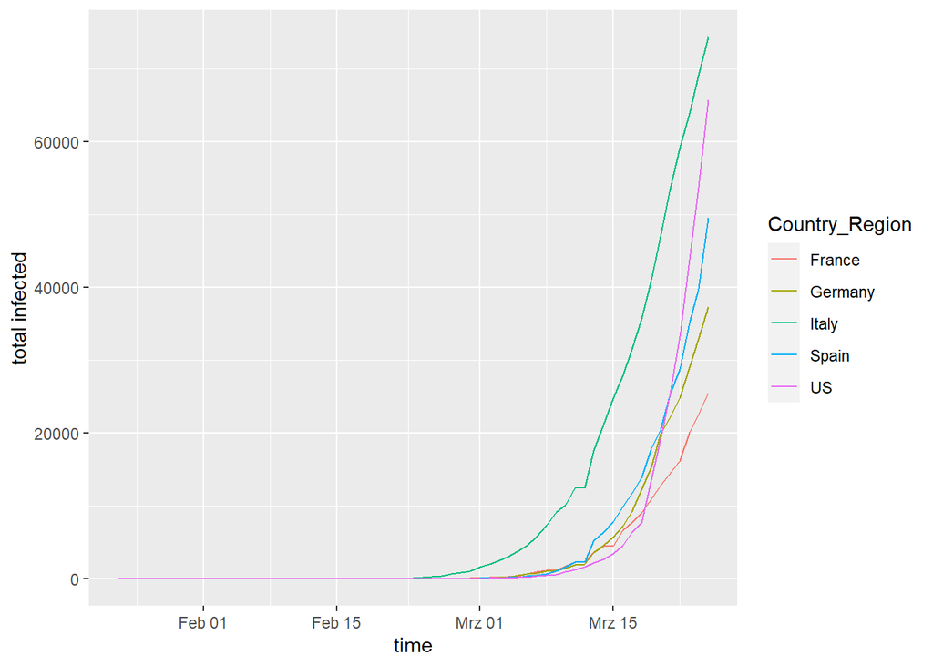

```r
dat2 %>%
  filter(Country_Region %in% c("Italy", "Spain","France", "Germany", "US"), !is.na(value)) %>%
  ggplot(aes(time, value, color=Country_Region)) +  geom_line() +
  labs(y = "total infected")
```

and with log-transformed scale. Small values < 100 are suppressed.

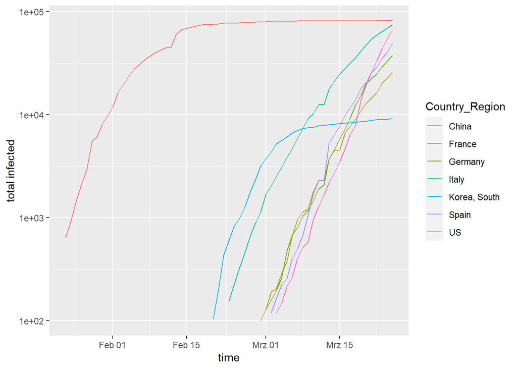

```r
dat2 %>%
  filter(value > 99) %>%
  filter(Country_Region %in% c("China", "Italy", "Spain","France", "Germany", "US", "Korea, South")) %>%
  ggplot(aes(time, value, color=Country_Region)) + geom_line() + scale_y_log10() +
  labs(y = "total infected")
```

## Rate of increase and doubling time

At the beginning of the epidemic, the number of infections $N$ can grow exponentially according to:

$$N = N_0 \cdot e^{r \cdot t}$$

so we can estimate the exponential rate of increase $r$ as:

$$r = \frac{\log{N_{t}}-log(N_{t-\Delta t})}{\Delta t}$$

The exponential rate of increase is shown, except for the last day, because recently reported data may not yet complete. The fluctuation of the data is very high, because they are the daily changes and as a result, standard errors (shadowed areas) are also very wide.

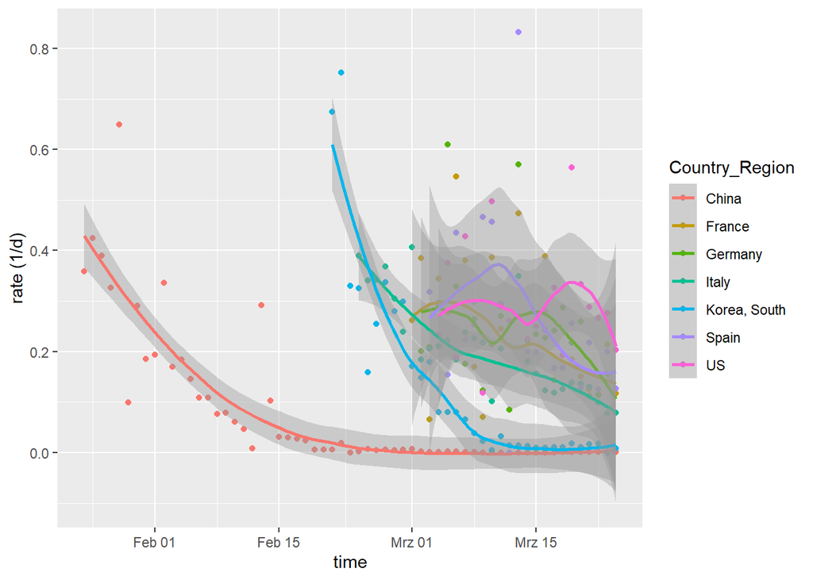

```r
dat2 %>%
  filter(value > 99, time < last(time)) %>%
  filter(Country_Region %in% c("China", "Italy", "Germany", "Spain", "France", "US", "Korea, South")) %>%
  mutate(log=log(value)) %>%  group_by(Country_Region) %>%
  mutate(growthrate = c(NA, diff(log)/diff(as.numeric(format(time, "%j"))))) %>%
  filter(!is.na(growthrate)) %>%
  ggplot(aes(time, growthrate, color=Country_Region)) +
  geom_point() + geom_smooth() + labs(y = "rate (1/d)")
```

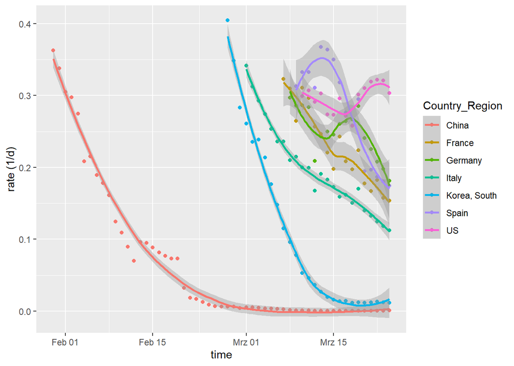

```r
lag <- 7
dat2 %>%
  filter(value > 99, time < last(time)) %>%
  filter(Country_Region %in% c("China", "Italy", "Germany", "France", "Spain", "US", "Korea, South")) %>%
  mutate(log = log(value)) %>%  group_by(Country_Region) %>%
  mutate(growthrate = c(rep(NA, lag), diff(log, lag = lag) / diff(as.numeric(format(time, "%j")), lag=lag))) %>%
  filter(!is.na(growthrate)) %>%
  ggplot(aes(time, growthrate, color=Country_Region)) +  geom_point() + geom_smooth() +  labs(y = "rate (1/d)")
```

An alternative to the rate of increase is the doubling time $t_d$:

$$t_d = \frac{\ln(2)}{r}$$
Here higher values are “good”. Unfortunately smoothing can introduce artifacts, because basic statistical assumptions may be violated. The choice of the smoother may change in the future. Note also that the use of a `lag` time hides short-term variation, so one should be very cautious with interpretations.

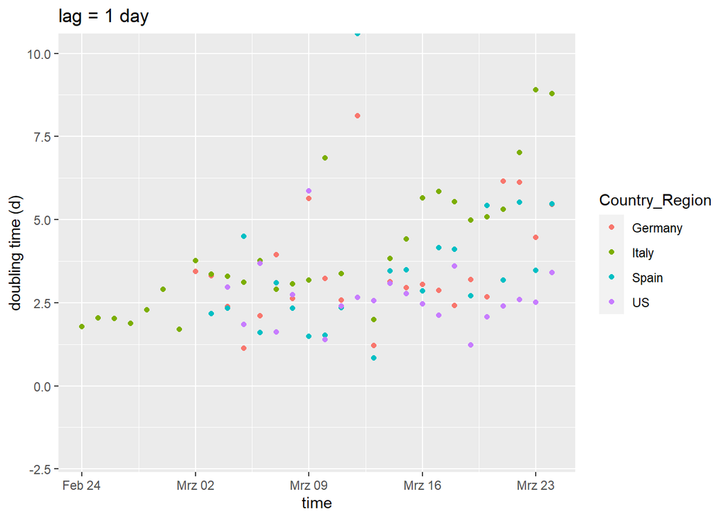

```r
lag <- 1
dat2 %>%
  filter(value > 99, time < last(time)) %>%
  filter(Country_Region %in% c("Italy", "Spain", "Germany", "US")) %>%
  mutate(log=log(value)) %>%
  group_by(Country_Region) %>%
  mutate(growthrate = c(rep(NA, lag), diff(log, lag = lag) / diff(as.numeric(format(time, "%j")), lag=lag))) %>%
  mutate(doubling = log(2) / growthrate) %>%
  filter(!is.na(doubling)) %>%
  ggplot(aes(time, doubling, color=Country_Region)) +
  geom_point() +
  #geom_smooth(se=FALSE) +
  coord_cartesian(ylim = c(-2, 10)) +
  labs(y = "doubling time (d)") + labs(title="lag = 1 day")
```

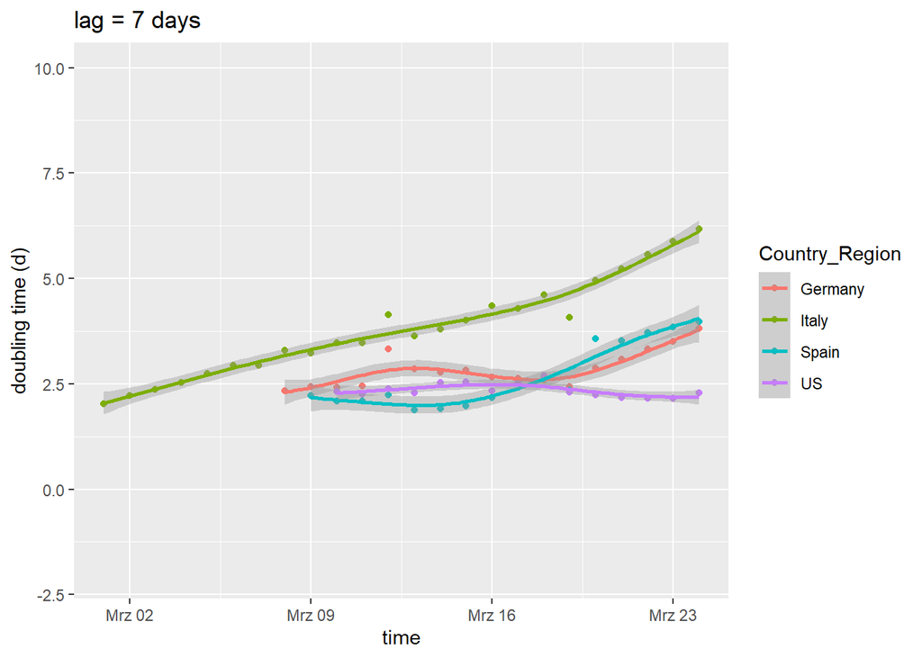

```r
lag <- 7
dat2 %>%
  filter(value > 99, time < last(time)) %>%
  filter(Country_Region %in% c("Italy", "Germany", "Spain", "US")) %>%
  mutate(log=log(value)) %>%
  group_by(Country_Region) %>%
  mutate(growthrate = c(rep(NA, lag), diff(log, lag = lag) / diff(as.numeric(format(time, "%j")), lag=lag))) %>%
  mutate(doubling = log(2) / growthrate) %>%
  filter(!is.na(doubling)) %>%
  ggplot(aes(time, doubling, color=Country_Region)) +
  geom_point() +
  geom_smooth(method="gam" ,formula=y ~ s(x, bs = "cr"), se=TRUE) +
  coord_cartesian(ylim = c(-2, 10)) +
  labs(y = "doubling time (d)", title="lag = 7 days")
```

## References

Data source: 2019 Novel Coronavirus COVID-19 (2019-nCoV) Data Repository by Johns Hopkins CSSE, https://github.com/CSSEGISandData/COVID-19

Dong, E., Du, H., & Gardner, L. (2020). An interactive web-based dashboard to track COVID-19 in real time. The Lancet Infectious Diseases, S1473309920301201. https://doi.org/10.1016/S1473-3099(20)30120-1

**Please consult the web page of the experts, e.g.: https://www.rki.de**

Additional links and related info: https://tpetzoldt.github.io/covid